# HW2

## 1.8 Make the model diagnostic plots shown in lab. Is there reason to be concerned about any of the model assumptions?

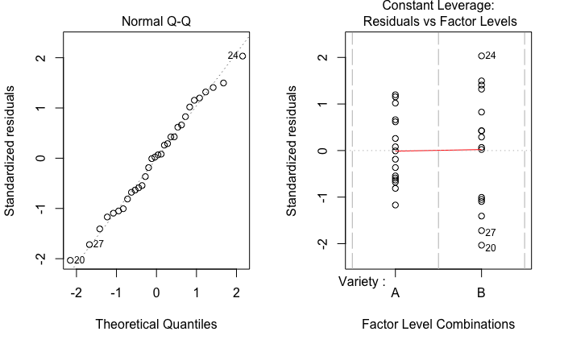

```r
par(mfrow=c(1,2))
plot(model_1,which = c(2,5))
```

> The data appear normally distributed. There may be slighly higher variance for Variety B than Variety A. This may impact the accurary of the confidence intervals / p-values because we assume the variances are the same.

> [4 points] You need to show both the boxplot (or another plot showing within-group variation) and a QQ-plot to receive full credit. 1 point off if you are missing either one. For future questions asking for model diagnostic plots please show both. Alternative interpretations are OK, as long as you give an explanation that is valid. It is a judgement call with these diagnostics.

## 1.9 Calculate the power of the test to detect a difference of 3cm, with n=16 and alpha = 0.1. Assume the within-variety standard deviation is is 2.5cm

```r
# see: ?power.t.test
power.t.test(n=16,delta = 3,sig.level = 0.1,sd = 2.5,alternative = 'two.sided')
```

```
     Two-sample t test power calculation

              n = 16
          delta = 3
             sd = 2.5
      sig.level = 0.1
          power = 0.9526615
    alternative = two.sided

NOTE: n is number in *each* group
```

> The power in this case would be 95%

> [4 points] For students that used sig.level = 0.9 because of the previous error in the homework and missed instruction, you can give yourself full credit.

## 1.10 Prepare a table showing the number of replicates required to detect significant differences (alpha = 0.01, power = 0.9) between means that are 1, 2, 4, 8, or 16 cm apart, assuming that the population standard deviation is 4cm. Use the function `power.t.test`. How much easier is it to detect a difference of 16cm than one of 1 cm?

```r
pop_sd = NA
delta = c(1,2,4,8,16)
reps = c(NA,NA,NA,NA,NA)
# Here's a hit at how to calculate the sample size for the first delta
# reps[1] <- power.t.test(n = ?,  # make sure to fill in ALL of the ?
#                         delta = delta[1],
#                         sd = 5,
#                         sig.level = ?,
#                         power = ?,
#                         type = ?,
#                         alternative = ?
#                           )$n
reps[1] <- power.t.test(n = NULL,  # make sure to fill in ALL of the ?
                        delta = delta[1],
                        sd = 4,
                        sig.level = 0.01,
                        power = 0.9,
                        type = 'two.sample',
                        alternative = 'two.sided'
                          )$n
reps[2] <- power.t.test(n = NULL,  # make sure to fill in ALL of the ?
                        delta = delta[2],
                        sd = 4,
                        sig.level = 0.01,
                        power = 0.9,
                        type = 'two.sample',
                        alternative = 'two.sided'
                          )$n
reps[3] <- power.t.test(n = NULL,  # make sure to fill in ALL of the ?
                        delta = delta[3],
                        sd = 4,
                        sig.level = 0.01,
                        power = 0.9,
                        type = 'two.sample',
                        alternative = 'two.sided'
                          )$n
reps[4] <- power.t.test(n = NULL,  # make sure to fill in ALL of the ?
                        delta = delta[4],
                        sd = 4,
                        sig.level = 0.01,
                        power = 0.9,
                        type = 'two.sample',
                        alternative = 'two.sided'
                          )$n
reps[5] <- power.t.test(n = NULL,  # make sure to fill in ALL of the ?
                        delta = delta[5],
                        sd = 4,
                        sig.level = 0.01,
                        power = 0.9,
                        type = 'two.sample',
                        alternative = 'two.sided'
                          )$n
# Here we make a table of the results. Note that we standardize the deltas by the population SD
ans_4.4 <- data.frame(delta,reps)
ans_4.4
```

| delta | reps |
| --- | --- |
| 1 | 477.802065 |
| 2 | 120.705488 |
| 4 | 31.462450 |
| 8 | 9.251528 |
| 16 | 3.850433 |

> [4 points] 3 points for the table, 1 point for a statement about how much more difficult it would be. It doesn’t have to be a quantitative statment.